# Mapping Fatalities from Attacks on Civilians in Darfur: 2016 vs. 2020

Visual 6

Rob Boswell

7-27-2023

- Previous Page
- Next Page

#### In creating a before vs. after UN base withdrawal comparison of violence against civilians, since Geo-PKO data on UNAMID troop numbers only extends to 2020, I will compare Darfur’s 2016 and 2020 maps. It is important though to keep in mind from Visual 2 that civilian killings were higher in Darfur as a whole in 2021 than 2020, and from Visual 3 that a significant rise in civilian killings occurred in West Darfur in 2021 compared to 2020.

#### In the maps below, between 2016 and 2020 the pattern of civilian attacks in Darfur shifted notably. In 2016, the deadliest attacks were highly concentrated at the intersection of Central, South, and North Darfur. However, by 2020 there were more high-fatality attacks in South Darfur, while West Darfur saw a significant rise in generally lower-fatality attacks coinciding with the withdrawal of UN bases and peacekeepers.

#### Both maps reveal a consistent pattern: administrative districts with the most civilian attacks had UN bases averaging a yearly troop strength of 200 or fewer.

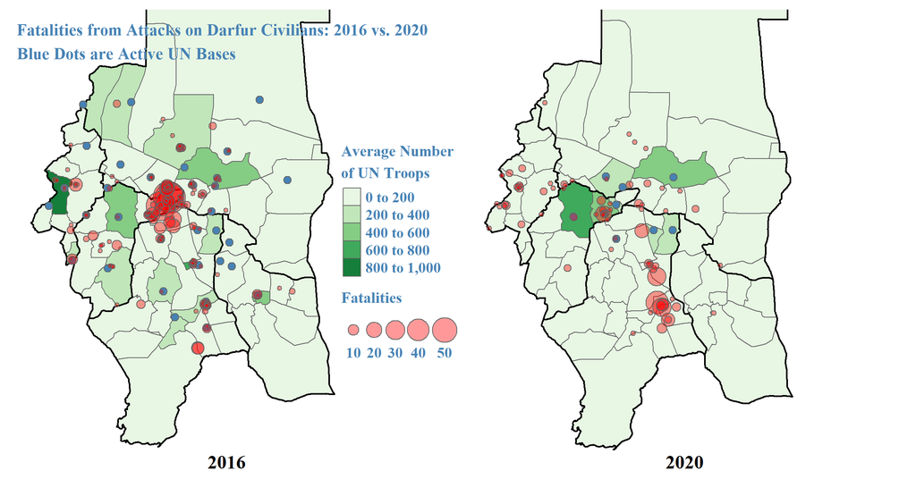

#### We have until now seen particularly interesting trends in West Darfur and South Darfur; in the next 2 visuals, I will visually compare violence in these 2 states within a 50 mi radius of bases closed from 2017-2019. Specifically, I will show violence levels the year before vs. the year of base withdrawals. Additionally, I will quantitatively measure levels of violence against civilians up until 2021 within these 50 mi radius buffers to see whether it increased or decreased following base withdrawals.

#### The analysis so far lends itself to the view that it is plausible the withdrawal of UN bases in these 2 regions may have been premature and allowed violence to spread.

- Previous Page
- Next Page